# Probabilistic alternative to 2 group t-test

Author

Rasmus Hindström

Published

July 22, 2025

# 0. Summary

This report demonstrates the use and interpretation of a probabilistic alternative to the two sample t-test. For a more expansive deep dive into the topic refer to Matti Vuorre’s blog post [How to Compare Two Groups with Robust Bayesian Estimation in R](https://vuorre.com/posts/2017-01-02-how-to-compare-two-groups-with-robust-bayesian-estimation-using-r-stan-and-brms/). Much of which is adapted here to the context of microbiome research.

A common task in microbiome research is to compare alpha diversity between two or more groups. Often done with the t-test and concluded as a binary “significant or non-significant” result, the more rich inference provided by the probabilistic comparison will become apparent. Alpha diversity is a measure of the within sample diversity, and it is often computed as the number of observed species (richness), the Shannon index, or the Simpson index. Here we demostrate comparisons of the Shannon index which takes into account abundance information, and is typically close to normally distributed.

# 1. Data preparation

Here a dataset from the `mia` package is used to demonstrate the comparison and interpretation differences between the two sample t-test (Welch t-test) and an alternative probabilistic approach with Bayesian estimation using the `brms` package.

```r
library(mia)
library(dplyr)
library(brms)
library(bayesplot)
```

```r
data("peerj13075", package = "mia")
tse <- peerj13075

tse <- addAlpha(
    tse,
    assay.type = "counts",
    index = "shannon"
)

df <- as.data.frame(colData(tse))
```

# 2. Bayesian estimation

As Matti Vuorre (2017) points out, the t-test is only a linear model under the hood. Extending this idea, we can formulate a probabilistic model and use `brms` to estimate the parameters of interest. In this case the group means and variances. Using a Student’s t-distribution and estimating $\nu$ allows for a more robust model that is less sensitive to outliers.

$$y_{ik} \sim \mathcal{T}(\nu, \mu_k, \sigma_k^2)$$

$$\mu_k = \beta_0 + \beta_k$$

$$\sigma_k^2 = \gamma_0 + \gamma_k$$

```r
# Fit Bayesian model (default priors)
fit <- brm(
    formula = bf(
        shannon ~ Diet,
        sigma ~ Diet
    ),
    data = df,
    family = student,
    iter = 4000,
    chains = 4,
    cores = 4
)
```

```r
summary(fit)
```

```
 Family: student
  Links: mu = identity; sigma = log; nu = identity
Formula: shannon ~ Diet
         sigma ~ Diet
   Data: df (Number of observations: 58)
  Draws: 4 chains, each with iter = 4000; warmup = 2000; thin = 1;
         total post-warmup draws = 8000

Regression Coefficients:
                Estimate Est.Error l-95% CI u-95% CI Rhat Bulk_ESS Tail_ESS
Intercept           1.26      0.16     0.94     1.59 1.00     8474     5371
sigma_Intercept    -0.21      0.15    -0.50     0.11 1.00     8612     5713
DietVeg            -0.02      0.20    -0.42     0.38 1.00     9134     5906
sigma_DietVeg      -0.25      0.21    -0.67     0.15 1.00     9135     5755

Further Distributional Parameters:
   Estimate Est.Error l-95% CI u-95% CI Rhat Bulk_ESS Tail_ESS
nu    24.06     14.70     5.63    61.55 1.00     8718     5712

Draws were sampled using sampling(NUTS). For each parameter, Bulk_ESS
and Tail_ESS are effective sample size measures, and Rhat is the potential
scale reduction factor on split chains (at convergence, Rhat = 1).
```

A straight forward interpretation of the model can be made from the 95% credible intervals (CIs). Here our baseline group is the Mixed diet. The intercept for DietVeg shows the difference in the Shannon index compared to the Mixed diet.

The CI for the intercept of DietVeg indicates that the difference between the two groups is likely to not be meaningful, as the CI includes 0.

## 2.1. Model diagnostics

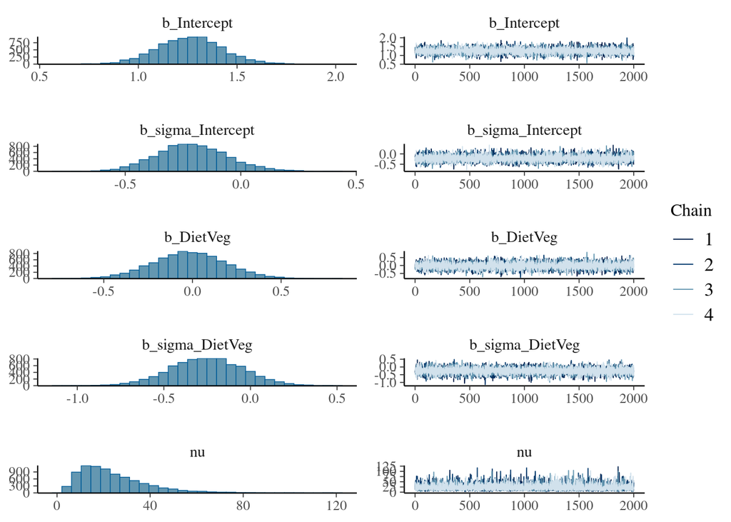

```r
plot(fit)
```

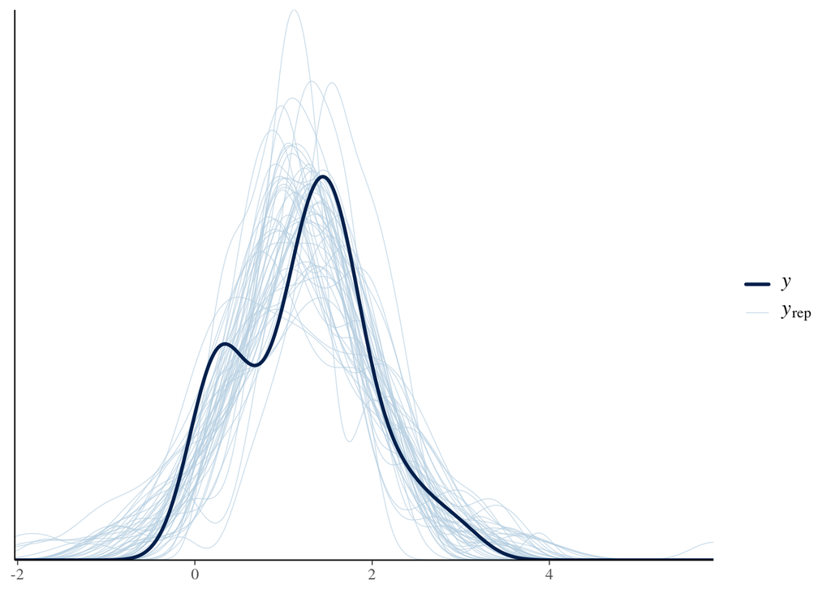

```r
pp_check(fit, ndraws = 50)
```

The model summary shows non-pathogenic Rhat values, indicating that the chains have converged. Effective sample sizes are sufficiently high (> 1000) for each parameter. Chains are well mixed in the traceplots. The posterior predictive plot shows that the model is able to capture the observed data well enough. However, the two peaked nature of the data is not captured.

# 3. Welch t-test

Welch t-test frees the assumption of equal variances between the two groups. It retains the assumption of normality.

In essence the t-test compares the means of two groups, and returns a p-value indicating the probability of observing the data if the null hypothesis is true. The p-value is computed as the probability of observing a t-statistic as extreme as the one computed from the data, under the null hypothesis. The null hypothesis states that there is no difference between the two groups.

```r
t.test(shannon ~ Diet, data = df, var.equal = FALSE)
```

```
    Welch Two Sample t-test

data:  shannon by Diet
t = 0.17328, df = 51.239, p-value = 0.8631
alternative hypothesis: true difference in means between group Mixed and group Veg is not equal to 0
95 percent confidence interval:
 -0.3593384  0.4272388
sample estimates:
mean in group Mixed   mean in group Veg
           1.270704            1.236754
```

The p-value suggests that there is no significant difference between the two groups. We fail to reject the null hypothesis.

# Bibliography

- Kruschke, J. K. (2013). Bayesian estimation supersedes the t test. Journal of Experimental Psychology: General, 142(2), 573–603. https://doi.org/10.1037/a0029146
- Vuorre, Matti. 2017. “How to Compare Two Groups with Robust Bayesian Estimation in R.” January 2, 2017. https://vuorre.com/posts/2017-01-02-how-to-compare-two-groups-with-robust-bayesian-estimation-using-r-stan-and-brms/.